# Assignment 2

## Andrey McLeggan

### 26Nov2024

#### Q1

```python
import pandas as pd
worldbank = pd.read_csv("worldbank_gapminder.csv")
```

#### Q2

```python
print(worldbank.dtypes)
```

[output not shown]

#### Q4

```python
worldbank["country"] = worldbank["country"].astype("category")
worldbank.continent=worldbank.continent.astype("category")
print(worldbank.dtypes)
```

```
Unnamed: 0       int64
country       category
continent     category
year             int64
lifeExp        float64
pop              int64
gdpPercap      float64
dtype: object
```

#### Q5

```python
worldbank.isnull().sum()
```

```
Unnamed: 0    0
country       0
continent     0
year          0
lifeExp       0
pop           0
gdpPercap     0
dtype: int64
```

#### Q6

```python
print(worldbank.shape)
```

```
(1704, 7)
```

#### I found this using the code above. There are 1704 rows and 7 columns

#### Q7

```python
worldbank.iloc[2]['lifeExp']
```

```
31.997
```

#### Q8

```python
worldbank["gdpPercap"].max()
```

```
113523.1329
```

#### Q9

```python
mean = worldbank["lifeExp"].mean()
print(mean)
sd = worldbank["lifeExp"].std()
print(sd)
```

```
59.474439366197174
12.917107415241187
```

#### Q10

```python
europe_df = worldbank[worldbank["continent"]=="Europe"]
print(europe_df)
```

```
      Unnamed: 0         country continent  year  lifeExp       pop  \
12            13         Albania    Europe  1952   55.230   1282697
13            14         Albania    Europe  1957   59.280   1476505
14            15         Albania    Europe  1962   64.820   1728137
15            16         Albania    Europe  1967   66.220   1984060
16            17         Albania    Europe  1972   67.690   2263554
...          ...             ...       ...   ...      ...       ...
1603        1604  United Kingdom    Europe  1987   75.007  56981620
1604        1605  United Kingdom    Europe  1992   76.420  57866349
1605        1606  United Kingdom    Europe  1997   77.218  58808266
1606        1607  United Kingdom    Europe  2002   78.471  59912431
1607        1608  United Kingdom    Europe  2007   79.425  60776238

         gdpPercap
12     1601.056136
13     1942.284244
14     2312.888958
15     2760.196931
16     3313.422188
...            ...
1603  21664.787670
1604  22705.092540
1605  26074.531360
1606  29478.999190
1607  33203.261280

[360 rows x 7 columns]
```

#### Q11

```python
print(europe_df.shape)
```

```
(360, 7)
```

#### The data frame contains 360 rows and 7 columns

#### Q12

```python
small_europe = europe_df[(europe_df["country"].isin(["Germany","Austria", "France"])) &
(europe_df["year"] == 2002)]
print(small_europe)
```

```
     Unnamed: 0  country continent  year  lifeExp       pop    gdpPercap
82           83  Austria    Europe  2002    78.98   8148312  32417.60769
538         539   France    Europe  2002    79.59  59925035  28926.03234
574         575  Germany    Europe  2002    78.67  82350671  30035.80198
```

#### Q13

#### Q14

```python
africa_df = worldbank[(worldbank["continent"]== "Africa") & ~worldbank["country"].isin(['Zambia','Tunisia'])]
mean_africa = africa_df["lifeExp"].mean()
sd_africa = africa_df["lifeExp"].std()
print(mean_africa)
print(sd_africa)
```

```
48.68559666666667
9.03331312960448
```

#### Q15

#### Q16

```python
worldbank["high_exp"] = (worldbank["lifeExp"] > 75).astype(int)
print(worldbank.head())
```

```
   Unnamed: 0      country continent  year  lifeExp       pop   gdpPercap  \
0           1  Afghanistan      Asia  1952   28.801   8425333  779.445314
1           2  Afghanistan      Asia  1957   30.332   9240934  820.853030
2           3  Afghanistan      Asia  1962   31.997  10267083  853.100710
3           4  Afghanistan      Asia  1967   34.020  11537966  836.197138
4           5  Afghanistan      Asia  1972   36.088  13079460  739.981106

   high_exp
0         0
1         0
2         0
3         0
4         0
```

#### Q17

```python
high_df = worldbank[worldbank["high_exp"]==1]
print(high_df.head())
```

```
    Unnamed: 0    country continent  year  lifeExp       pop     gdpPercap  \
22          23    Albania    Europe  2002   75.651   3508512   4604.211737
23          24    Albania    Europe  2007   76.423   3600523   5937.029526
59          60  Argentina  Americas  2007   75.320  40301927  12779.379640
67          68  Australia   Oceania  1987   76.320  16257249  21888.889030
68          69  Australia   Oceania  1992   77.560  17481977  23424.766830

    high_exp
22         1
23         1
59         1
67         1
68         1
```

#### Q18

```python
low_df = worldbank[worldbank["high_exp"]==0]
print(low_df.head())
```

```
   Unnamed: 0      country continent  year  lifeExp       pop   gdpPercap  \
0           1  Afghanistan      Asia  1952   28.801   8425333  779.445314
1           2  Afghanistan      Asia  1957   30.332   9240934  820.853030
2           3  Afghanistan      Asia  1962   31.997  10267083  853.100710
3           4  Afghanistan      Asia  1967   34.020  11537966  836.197138
4           5  Afghanistan      Asia  1972   36.088  13079460  739.981106

   high_exp
0         0
1         0
2         0
3         0
4         0
```

### Q19

```python
mean_gdph = high_df["gdpPercap"].mean()
mean_gdpl = low_df["gdpPercap"].mean()
print(mean_gdph)
print(mean_gdpl)
```

```
24704.287164069363
5239.108861529393
```

### Q20

```python
gdpmean = {"greater_75": worldbank[worldbank["lifeExp"] > 75]["gdpPercap"].mean(),
           "lessEqual_75": worldbank[worldbank["lifeExp"]<= 75]["gdpPercap"].mean()
          }
print(gdpmean)
```

```
{'greater_75': 24704.287164069363, 'lessEqual_75': 5239.108861529393}
```

#### Q21

```python
pd.crosstab(worldbank["continent"],worldbank["high_exp"]==1, normalize="index")
```

| high_exp continent | False | True |
| --- | --- | --- |
| Africa | 0.996795 | 0.003205 |
| Americas | 0.906667 | 0.093333 |
| Asia | 0.916667 | 0.083333 |
| Europe | 0.719444 | 0.280556 |
| Oceania | 0.625000 | 0.375000 |

#### Q22

#### Roughly 9%

#### Q23

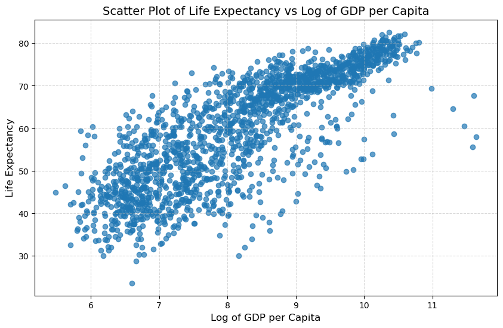

```python
import numpy as np
import matplotlib.pyplot as plt

worldbank['log_gdpPercap'] = np.log(worldbank['gdpPercap'])

plt.figure(figsize=(10, 6))
plt.scatter(worldbank['log_gdpPercap'], worldbank['lifeExp'], alpha=0.7)
plt.title('Scatter Plot of Life Expectancy vs Log of GDP per Capita', fontsize=14)
plt.xlabel('Log of GDP per Capita', fontsize=12)
plt.ylabel('Life Expectancy', fontsize=12)
plt.grid(True, linestyle='--', alpha=0.5)
plt.show()
```

#### Drawing from this plot and the one in question number 25, I can see that there is a positive correlation between GDP and life expectancy. They relationship seems to be that the higher the GDP, the higher the life expectancy. There also seems to be some outliar countries in the continent of Asia, but overall, the trend seems positive with most of the higher life expectancy being in the Americas and Europe.This can be explained by the fact that higher GDP countries tend to have better infastructure, water treatment, and medical assets. The higher qualifty of life from these more developed nations would explain the relationship seen on the charts.

#### Q24

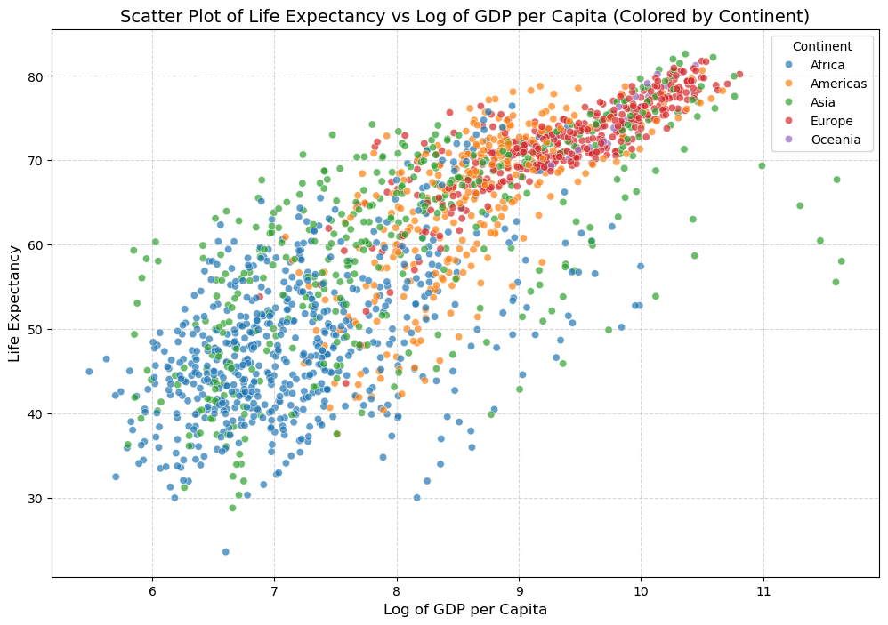

```python
import seaborn as sns

plt.figure(figsize=(12, 8))
sns.scatterplot(
    data=worldbank,
    x='log_gdpPercap',
    y='lifeExp',
    hue='continent',
    palette='tab10',
    alpha=0.7
)
plt.title('Scatter Plot of Life Expectancy vs Log of GDP per Capita (Colored by Continent)', fontsize=14)
plt.xlabel('Log of GDP per Capita', fontsize=12)
plt.ylabel('Life Expectancy', fontsize=12)
plt.legend(title='Continent', fontsize=10)
plt.grid(True, linestyle='--', alpha=0.5)
plt.show()
```

### Q25

#### list comprehension is a cleaner was to create a new list by applying an operation to each item in the list in a single code

```python
import altair as alt

scatter_plot = alt.Chart(worldbank).mark_circle(size=60, opacity=0.7).encode(
    x=alt.X('log_gdpPercap', title='Log of GDP per Capita'),
    y=alt.Y('lifeExp', title='Life Expectancy'),
    color=alt.Color('continent', title='Continent'),
    tooltip=['continent', 'country', 'year']
).properties(
    title='Scatter Plot of Life Expectancy vs Log of GDP per Capita by Continent',
    width=800,
    height=500
)

scatter_plot
```

[interactive chart not shown]